# Coursera & JHU: Reproductible Research Week 2 Peer-graded Assignment

Ana Guardia

24 de febrero de 2018

## Part 0: Loading and preprocessing the data

```r
df <- read.csv("activity.csv", header = TRUE, sep = ",")

head(df)
```

```
##   steps       date interval
## 1    NA 2012-10-01        0
## 2    NA 2012-10-01        5
## 3    NA 2012-10-01       10
## 4    NA 2012-10-01       15
## 5    NA 2012-10-01       20
## 6    NA 2012-10-01       25
```

```r
str(df)
```

```
## 'data.frame':    17568 obs. of  3 variables:
##  $ steps   : int  NA NA NA NA NA NA NA NA NA NA ...
##  $ date    : Factor w/ 61 levels "2012-10-01","2012-10-02",..: 1 1 1 1 1 1 1 1 1 1 ...
##  $ interval: int  0 5 10 15 20 25 30 35 40 45 ...
```

```r
summary(df)
```

```
##      steps                date          interval
##  Min.   :  0.00   2012-10-01:  288   Min.   :   0.0
##  1st Qu.:  0.00   2012-10-02:  288   1st Qu.: 588.8
##  Median :  0.00   2012-10-03:  288   Median :1177.5
##  Mean   : 37.38   2012-10-04:  288   Mean   :1177.5
##  3rd Qu.: 12.00   2012-10-05:  288   3rd Qu.:1766.2
##  Max.   :806.00   2012-10-06:  288   Max.   :2355.0
##  NA's   :2304     (Other)   :15840
```

## Part 1: What is mean total number of steps taken per day?

### 1. Calculate the total number of steps taken per day

```r
spd<-aggregate(steps~date,FUN=sum,data=df)
summary(spd)
```

```
##          date        steps
##  2012-10-02: 1   Min.   :   41
##  2012-10-03: 1   1st Qu.: 8841
##  2012-10-04: 1   Median :10765
##  2012-10-05: 1   Mean   :10766
##  2012-10-06: 1   3rd Qu.:13294
##  2012-10-07: 1   Max.   :21194
##  (Other)   :47
```

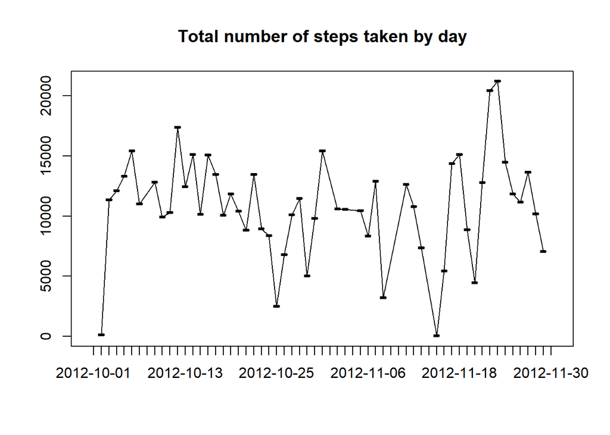

### 2. Make a histogram of the total number of steps taken each day

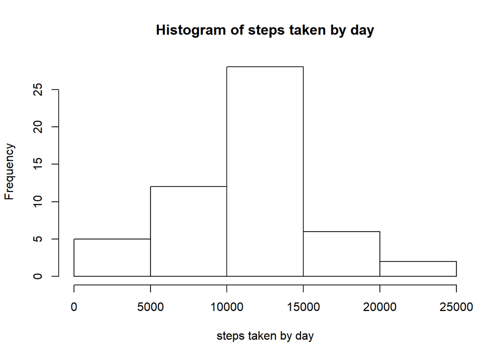

### 3. Calculate and report the mean and median of the total number of steps taken per day

```r
mean(yspd)
```

```
## [1] 10766.19
```

```r
median(yspd)
```

```
## [1] 10765
```

*Note: For this part of the assignment, you can ignore the missing values in the dataset.*

## Part 2: What is the average daily activity pattern?

### Make a time series plot (i.e. type = “l”) of the 5-minute interval (x-axis) and the average number of steps taken, averaged across all days (y-axis)

```r
spi<-aggregate(steps~interval,FUN=mean,data=df)
summary(spi)
```

```
##     interval          steps
##  Min.   :   0.0   Min.   :  0.000
##  1st Qu.: 588.8   1st Qu.:  2.486
##  Median :1177.5   Median : 34.113
##  Mean   :1177.5   Mean   : 37.383
##  3rd Qu.:1766.2   3rd Qu.: 52.835
##  Max.   :2355.0   Max.   :206.170
```

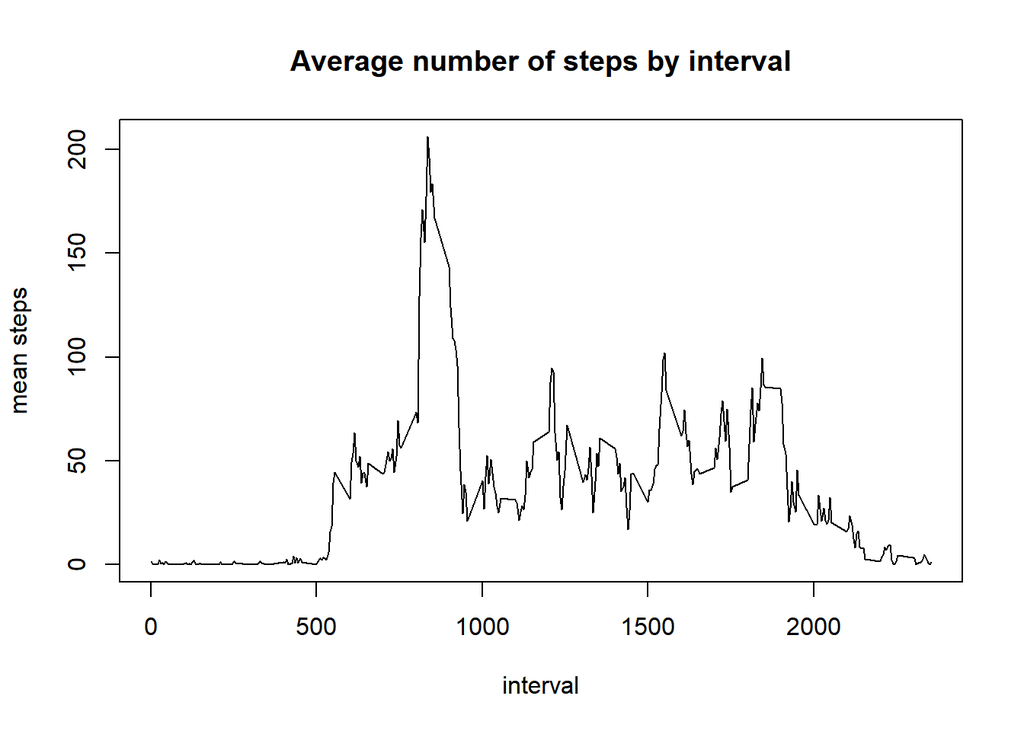

### Which 5-minute interval, on average across all the days in the dataset, contains the maximum number of steps?

```r
spi[yspi==max(yspi),]
```

```
##     interval    steps
## 104      835 206.1698
```

## Part 3: Imputing missing values

*Note that there are a number of days/intervals where there are missing values (coded as NA). The presence of missing days may introduce bias into some calculations or summaries of the data.*

### 1. Calculate and report the total number of missing values in the dataset (i.e. the total number of rows with NAs)

```r
sum(is.na(df$steps))
```

```
## [1] 2304
```

### 2. Devise a strategy for filling in all of the missing values in the dataset. The strategy does not need to be sophisticated. For example, you could use the mean/median for that day, or the mean for that 5-minute interval, etc.

I will use the mean for that 5-minute interval.

### 4. Create a new dataset that is equal to the original dataset but with the missing data filled in.

```r
dfNA<-df
dfNA$steps[is.na(df$steps)] <- spi$steps[match(df$interval,spi$interval)][which(is.na(df$steps))]
head(dfNA)
```

```
##       steps       date interval
## 1 1.7169811 2012-10-01        0
## 2 0.3396226 2012-10-01        5
## 3 0.1320755 2012-10-01       10
## 4 0.1509434 2012-10-01       15
## 5 0.0754717 2012-10-01       20
## 6 2.0943396 2012-10-01       25
```

Check

```r
sum(is.na(dfNA$steps))
```

```
## [1] 0
```

### 5. Make a histogram of the total number of steps taken each day.

[figure not shown]

```r
mean(yna)
```

```
## [1] 37.3826
```

```r
median(yna)
```

```
## [1] 0
```

### What is the impact of imputing missing data on the estimates of the total daily number of steps?

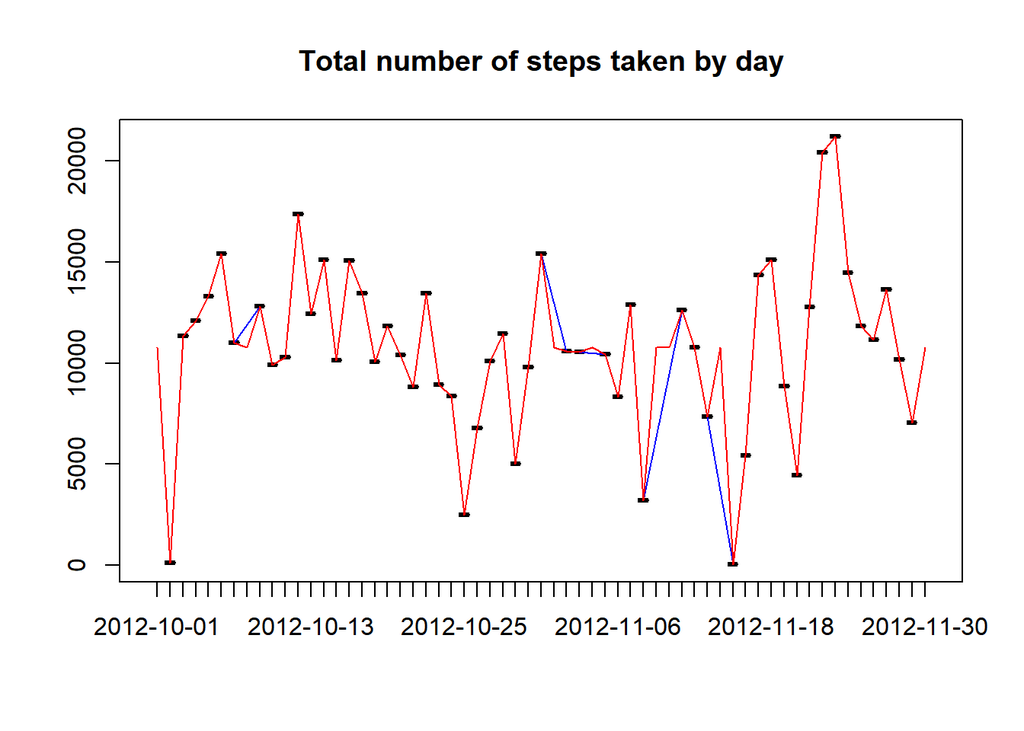

### Part 4: Are there differences in activity patterns between weekdays and weekends?

For this part the `weekdays()` function may be of some help here. Use the dataset with the filled-in missing values for this part.

1. Create a new factor variable in the dataset with two levels – “weekday” and “weekend” indicating whether a given date is a weekday or weekend day.

```r
Sys.setlocale("LC_ALL","English")
```

```
## [1] "LC_COLLATE=English_United States.1252;LC_CTYPE=English_United States.1252;LC_MONETARY=English_United States.1252;LC_NUMERIC=C;LC_TIME=English_United States.1252"
```

```r
dfNA$date <- as.Date(dfNA$date)
#create a vector of weekdays
weekdays <- c('Monday', 'Tuesday', 'Wednesday', 'Thursday', 'Friday')
#Use `%in%` and `weekdays` to create a logical vector
#convert to `factor` and specify the `levels/labels`
dfNA$wDay <- factor((weekdays(dfNA$date) %in% weekdays),
                    levels=c(FALSE, TRUE), labels=c('weekend', 'weekday'))
summary(dfNA)
```

```
##      steps             date               interval           wDay
##  Min.   :  0.00   Min.   :2012-10-01   Min.   :   0.0   weekend: 4608
##  1st Qu.:  0.00   1st Qu.:2012-10-16   1st Qu.: 588.8   weekday:12960
##  Median :  0.00   Median :2012-10-31   Median :1177.5
##  Mean   : 37.38   Mean   :2012-10-31   Mean   :1177.5
##  3rd Qu.: 27.00   3rd Qu.:2012-11-15   3rd Qu.:1766.2
##  Max.   :806.00   Max.   :2012-11-30   Max.   :2355.0
```

2. Make a panel plot containing a time series plot (i.e. type = “l”) of the 5-minute interval (x-axis) and the average number of steps taken, averaged across all weekday days or weekend days (y-axis). See the README file in the GitHub repository to see an example of what this plot should look like using simulated data.

```r
msteps<-aggregate(dfNA$steps, list(dfNA$interval,dfNA$wDay), mean)
colnames(msteps)[1]<-"interval"
colnames(msteps)[2]<-"wDay"
colnames(msteps)[3]<-"meansteps"
summary(msteps)
```

```
##     interval           wDay       meansteps
##  Min.   :   0.0   weekend:288   Min.   :  0.000
##  1st Qu.: 588.8   weekday:288   1st Qu.:  2.047
##  Median :1177.5                 Median : 28.133
##  Mean   :1177.5                 Mean   : 38.988
##  3rd Qu.:1766.2                 3rd Qu.: 61.263
##  Max.   :2355.0                 Max.   :230.378
```

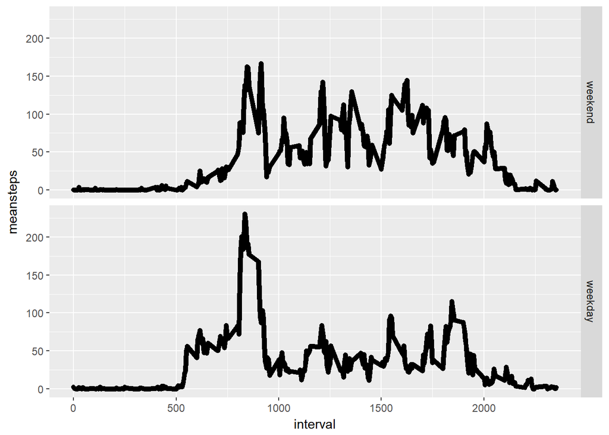